# Lab 2: Linear Regression

The purpose of this lab is to give you some hands on experience applying linear regression to a real-world dataset. We will use a truncated version of the Divvy Bike Share dataset that we used in the last lecture.

## Learning Objectives

In this lab, you should gain experience applying linear regression to a real-world dataset, after exploring the linear relationships in the dataset. You will also learn to apply some basic metrics for the goodness of fit of your linear regresison model.

After completing this lab, you should be able to:

1. Manipulate a dataset in Python/Pandas/Jupyter Notebooks.
2. Learn about the importance of pre-processing your dataset, as well as how to do so. You should learn about:
   - Various ways to truncate and subset your data.
   - Normalizing your dataset in preparation for training and testing.
3. Learn how to apply the `scikit-learn` Linear Regression model to a real-world dataset, based on concepts that we covered in class. You should learn about:
   - Splitting your data into a training and testing set.
   - Creating a model.
   - Combining data and metrics from multiple models.
4. Learn how to evaluate your model. You should learn how to evaluate the various aspects of feature importance in your dataset, including MAE, MSE and $R^2$.

## 1. Loading and Preparing Your Datasets

### 1.1 Load the Divvy Bike Share Data

Download the smaller version of the [Divvy Trip data](https://data.cityofchicago.org/Transportation/Divvy-Trips/fg6s-gzvg) that we have provided on Box called `Divvy_Trips_2018.csv.gz`. Load this as a Pandas data frame.

```python
import pandas as pd
import numpy as np
import seaborn as sns
import matplotlib.pyplot as plt
from sklearn.model_selection import train_test_split
from sklearn import preprocessing
from sklearn import metrics
from sklearn.preprocessing import StandardScaler
from sklearn import datasets, linear_model
import warnings
warnings.filterwarnings('ignore')

regr = linear_model.LinearRegression()
```

```python
ddf = pd.read_csv("/Users/mayar/Downloads/Divvy_Trips_2018.csv")
```

```python
ddf.head(2)
```

|  | TRIP ID | START TIME | STOP TIME | BIKE ID | TRIP DURATION | FROM STATION ID | FROM STATION NAME | TO STATION ID | TO STATION NAME | USER TYPE | GENDER | BIRTH YEAR | FROM LATITUDE | FROM LONGITUDE | FROM LOCATION | TO LATITUDE | TO LONGITUDE | TO LOCATION |
| --- | --- | --- | --- | --- | --- | --- | --- | --- | --- | --- | --- | --- | --- | --- | --- | --- | --- | --- |
| 0 | 18511623 | 05/21/2018 05:07:29 PM | 05/21/2018 05:11:48 PM | 153 | 259 | 51 | Clark St & Randolph St | 91 | Clinton St & Washington Blvd | Subscriber | Male | 1982.0 | 41.884576 | -87.631890 | POINT (-87.63188991 41.884576228) | 41.883380 | -87.641170 | POINT (-87.64117 41.88338) |
| 1 | 18002370 | 04/01/2018 02:24:43 PM | 04/01/2018 02:38:54 PM | 3101 | 851 | 106 | State St & Pearson St | 174 | Canal St & Madison St | Subscriber | Female | 1990.0 | 41.897448 | -87.628722 | POINT (-87.628722 41.897448) | 41.882091 | -87.639833 | POINT (-87.639833 41.882091) |

### 1.2 Load the Weather Data from NOAA

We have downloaded some historical weather data for Chicago from the National Oceanic and Atmospheric Administration (NOAA) and provided the dataset on Box for download under `chicago-weather.csv.gz`. Load this as a Pandas data frame.

If you are curious about how we obtained the dataset, you can read about the available data (and make your own requests) [here](https://www.ncdc.noaa.gov/cdo-web/search).You will also find this [documentation](https://www1.ncdc.noaa.gov/pub/data/cdo/documentation/GHCND_documentation.pdf) about the dataset useful, particularly the part describing the meanings of various columns.

```python
wdf = pd.read_csv("/Users/mayar/Downloads/chicago-weather.csv")
```

```python
wdf.head(2)
```

|  | STATION | NAME | DATE | AWND | DAPR | MDPR | PGTM | PRCP | SNOW | SNWD | TAVG | TMAX | TMIN | TOBS | WDF2 | WDF5 | WDMV | WSF2 | WSF5 |
| --- | --- | --- | --- | --- | --- | --- | --- | --- | --- | --- | --- | --- | --- | --- | --- | --- | --- | --- | --- |
| 0 | US1ILDP0098 | DOWNERS GROVE 0.9 S, IL US | 2018-03-28 | NaN | NaN | NaN | NaN | 0.00 | 0.0 | NaN | NaN | NaN | NaN | NaN | NaN | NaN | NaN | NaN | NaN |
| 1 | US1ILDP0098 | DOWNERS GROVE 0.9 S, IL US | 2018-03-29 | NaN | NaN | NaN | NaN | 0.12 | NaN | NaN | NaN | NaN | NaN | NaN | NaN | NaN | NaN | NaN | NaN |

### 1.3 Basic Data Analysis and Manipulation

We have provided some summary code below from the last lab, formatted to give you a good sense of what the datasets entail, as far as size, dates, and so forth. Note that in this example, the Divvy data frame is called `ddf` and the weather data frame is called `wdf`.

Let's do a brief review/overview of the data just to see what we have. This is a bit of a review of last week.

#### 1.4.1 How many rows are in each dataset, and what date ranges do the dataset span?

This one we've done for you, to get you started, since it's a review from last week.

```python
print("""
Divvy Data
----------
{} Rows
First Ride: {}, Last Ride {}

Weather Data
----------
{} Rows
First Measurement: {}, Last Measurement {}
"""
      .format(
          ddf.shape[0],
          ddf['START TIME'].min(),
          ddf['START TIME'].max(),
          wdf.shape[0],
          wdf['DATE'].min(),
          wdf['DATE'].max()
     ))
```

```
Divvy Data
----------
3602745 Rows
First Ride: 01/01/2018 01:00:00 AM, Last Ride 12/31/2018 12:59:05 PM

Weather Data
----------
79643 Rows
First Measurement: 2018-01-01, Last Measurement 2019-12-31
```

We can see from the above, first of all, that the date ranges overlap, but that they aren't perfectly overlapping. We'd like to work with data from a common date range from both datasets (and ideally a smaller sample, to start with!) so below we'll ask you to truncate the data. Before we get there, though, let's try to understand the weather dataset a bit more.

#### 1.4.2 Understanding the weather data

We can take a quick look at the weather data, since we haven't had the chance to look at that before. Call `describe` to take a look at the overall statistics.

```python
wdf.describe()
```

|  | AWND | DAPR | MDPR | PGTM | PRCP | SNOW | SNWD | TAVG | TMAX | TMIN | TOBS | WDF2 | WDF5 | WDMV | WSF2 | WSF5 |
| --- | --- | --- | --- | --- | --- | --- | --- | --- | --- | --- | --- | --- | --- | --- | --- | --- |
| count | 2185.000000 | 1303.000000 | 1295.00000 | 1458.000000 | 77491.000000 | 45370.000000 | 20556.000000 | 730.000000 | 7020.000000 | 7028.000000 | 4847.000000 | 2188.000000 | 2187.000000 | 211.000000 | 2188.000000 | 2187.000000 |
| mean | 8.991611 | 4.745971 | 0.74088 | 1287.608368 | 0.143893 | 0.126284 | 0.815723 | 50.401370 | 58.903704 | 41.498435 | 46.585723 | 185.219378 | 185.939643 | 17.302370 | 19.078748 | 26.426566 |
| std | 3.543335 | 4.535482 | 0.99868 | 599.380253 | 0.364978 | 0.601270 | 2.222117 | 20.566444 | 21.807682 | 19.988210 | 19.869322 | 107.819971 | 105.813504 | 17.424486 | 5.611734 | 8.363227 |
| min | 1.340000 | 2.000000 | 0.00000 | 0.000000 | 0.000000 | 0.000000 | 0.000000 | -15.000000 | -12.000000 | -24.000000 | -23.000000 | 10.000000 | 10.000000 | 0.000000 | 6.000000 | 6.900000 |
| 25% | 6.490000 | 2.000000 | 0.11000 | 950.000000 | 0.000000 | 0.000000 | 0.000000 | 34.000000 | 41.000000 | 27.000000 | 31.000000 | 80.000000 | 80.000000 | 6.200000 | 15.000000 | 19.900000 |
| 50% | 8.500000 | 3.000000 | 0.44000 | 1337.000000 | 0.000000 | 0.000000 | 0.000000 | 48.000000 | 58.000000 | 40.000000 | 46.000000 | 200.000000 | 200.000000 | 13.000000 | 18.100000 | 25.100000 |
| 75% | 11.180000 | 5.000000 | 0.98500 | 1646.750000 | 0.100000 | 0.000000 | 0.000000 | 70.000000 | 79.000000 | 60.000000 | 65.000000 | 270.000000 | 270.000000 | 24.200000 | 23.000000 | 31.100000 |
| max | 25.950000 | 49.000000 | 9.66000 | 2359.000000 | 6.520000 | 10.500000 | 24.000000 | 87.000000 | 102.000000 | 82.000000 | 88.000000 | 360.000000 | 360.000000 | 156.000000 | 46.100000 | 67.100000 |

**Number of readings**

The first thing you should note is that there are two years of data, but there are different numbers of readings for each type of weather measurement. Based on the summary statistics above, which variable would you suspect reflects one reading per day? Write your answer below:

*TAVG: Because there any several stations*

You should also immediately see that many of these columns have more than one measurement per day. Try to find out the reason for this. Some of the exercises below walk you through this exploration.

**How many unique weather stations are there?**

```python
print("Number of unique weather stations: {}".format(wdf.STATION.nunique()))
```

```
Number of unique weather stations: 165
```

## 2. Exploring the Data Visually

**How many readings does each weather station have?**

Show a plot that has the stations on the x-axis and the number of readings for that station on the y-axis. There are too many stations for a clean x label, so if possible just clean the x-axis up so that there are not a bunch of unreadable names. (We used Seaborn's `lineplot` function which automatically cleans things up, but you are welcome to take a different approach.) Be sure to label your axes.

```python
wdf['READINGS'] = 1
```

```python
wwdf = wdf[["STATION", "READINGS"]]
wwdf = wwdf.groupby('STATION').count().reset_index()
```

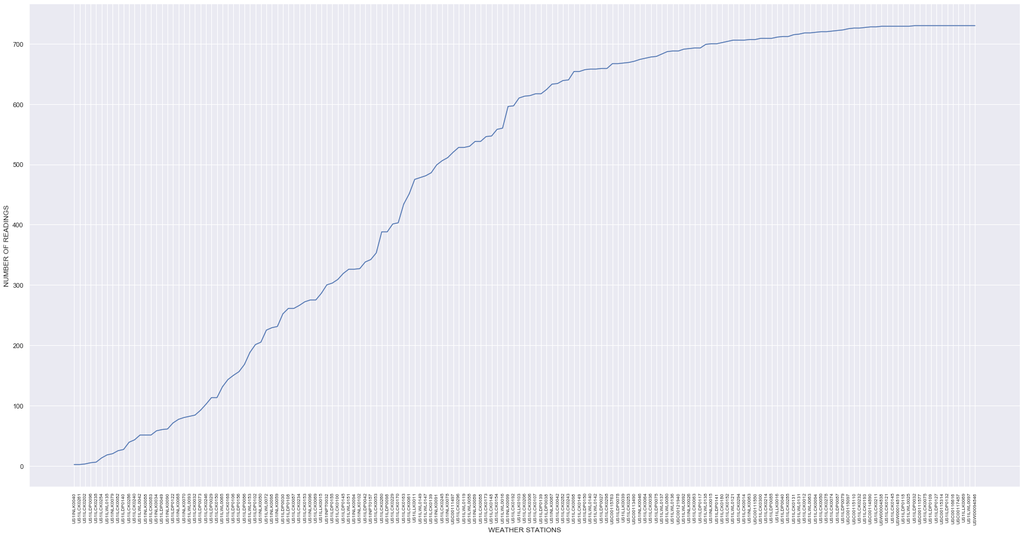

```python
%matplotlib inline

sns.set(rc={'figure.figsize':(30, 15)})
wwdf = wwdf.sort_values(['READINGS'])
ax = sns.lineplot(x ='STATION', y = 'READINGS', data=wwdf, sort=False)
ax.set(xlabel="WEATHER STATIONS", ylabel = "NUMBER OF READINGS")
plt.draw()
labels = ax.get_xticklabels()
ax.set_xticklabels(labels, rotation=90, fontsize = 8)
plt.show()
```

**What is the maximum number of readings that any station has?**

Note that this number should make sense, as a sanity check.

```python
print("The maximum number of readings a stations could have: {}".format(wwdf['READINGS'].max()))
```

```
The maximum number of readings a stations could have: 730
```

**Which stations have the maximum number of readings?**

Show your answer in a data frame. Hint: There are 12.

```python
rslt_df = wwdf[(wwdf['READINGS'] == 730)]
rslt_df
```

|  | STATION | READINGS |
| --- | --- | --- |
| 12 | US1ILCK0075 | 730 |
| 66 | US1ILDP0032 | 730 |
| 83 | US1ILDP0109 | 730 |
| 87 | US1ILDP0127 | 730 |
| 88 | US1ILDP0132 | 730 |
| 100 | US1ILLK0069 | 730 |
| 112 | US1ILWL0097 | 730 |
| 152 | USC00111577 | 730 |
| 157 | USC00115314 | 730 |
| 159 | USC00116616 | 730 |
| 160 | USC00117457 | 730 |
| 164 | USW00094846 | 730 |

## 3. Preparing the Datasets

### 3.1 Preparing the Weather Data

#### 3.1.1 Selecting the appropriate fields

**Build a data frame that contains (1) the date (2) the low temperature and (3) the high temperature for the Chicago Midway Airport station. Print the first few rows of the data frame.**

```python
wdf[wdf['NAME'].str.contains("CHICAGO MIDWAY")].head()
```

|  | STATION | NAME | DATE | AWND | DAPR | MDPR | PGTM | PRCP | SNOW | SNWD | TAVG | TMAX | TMIN | TOBS | WDF2 | WDF5 | WDMV | WSF2 | WSF5 | READINGS |
| --- | --- | --- | --- | --- | --- | --- | --- | --- | --- | --- | --- | --- | --- | --- | --- | --- | --- | --- | --- | --- |
| 32098 | USC00111577 | CHICAGO MIDWAY AIRPORT 3 SW, IL US | 2018-01-01 | NaN | NaN | NaN | NaN | 0.0 | 0.0 | 2.0 | NaN | 3.0 | -7.0 | -5.0 | NaN | NaN | NaN | NaN | NaN | 1 |
| 32099 | USC00111577 | CHICAGO MIDWAY AIRPORT 3 SW, IL US | 2018-01-02 | NaN | NaN | NaN | NaN | 0.0 | 0.0 | 2.0 | NaN | 7.0 | -10.0 | 7.0 | NaN | NaN | NaN | NaN | NaN | 1 |
| 32100 | USC00111577 | CHICAGO MIDWAY AIRPORT 3 SW, IL US | 2018-01-03 | NaN | NaN | NaN | NaN | 0.0 | 0.2 | 2.0 | NaN | 18.0 | 7.0 | 8.0 | NaN | NaN | NaN | NaN | NaN | 1 |
| 32101 | USC00111577 | CHICAGO MIDWAY AIRPORT 3 SW, IL US | 2018-01-04 | NaN | NaN | NaN | NaN | 0.0 | 0.0 | 2.0 | NaN | 13.0 | 2.0 | 3.0 | NaN | NaN | NaN | NaN | NaN | 1 |
| 32102 | USC00111577 | CHICAGO MIDWAY AIRPORT 3 SW, IL US | 2018-01-05 | NaN | NaN | NaN | NaN | 0.0 | 0.0 | 2.0 | NaN | 12.0 | 0.0 | 3.0 | NaN | NaN | NaN | NaN | NaN | 1 |

```python
wdf2 = wdf[wdf['STATION'] == 'USC00111577']
wdf2 = wdf2[["DATE", "TMAX", "TMIN"]]
wdf2
```

|  | DATE | TMAX | TMIN |
| --- | --- | --- | --- |
| 32098 | 2018-01-01 | 3.0 | -7.0 |
| 32099 | 2018-01-02 | 7.0 | -10.0 |
| 32100 | 2018-01-03 | 18.0 | 7.0 |
| 32101 | 2018-01-04 | 13.0 | 2.0 |
| 32102 | 2018-01-05 | 12.0 | 0.0 |
| ... | ... | ... | ... |
| 32823 | 2019-12-27 | 40.0 | 30.0 |
| 32824 | 2019-12-28 | 51.0 | 30.0 |
| 32825 | 2019-12-29 | 58.0 | 48.0 |
| 32826 | 2019-12-30 | 48.0 | 28.0 |
| 32827 | 2019-12-31 | 30.0 | 26.0 |

730 rows × 3 columns

**Plot the daily high and low temperature for Midway Airport for the duration of the dataset.**

Does this match your expectations for what the plot should look like?

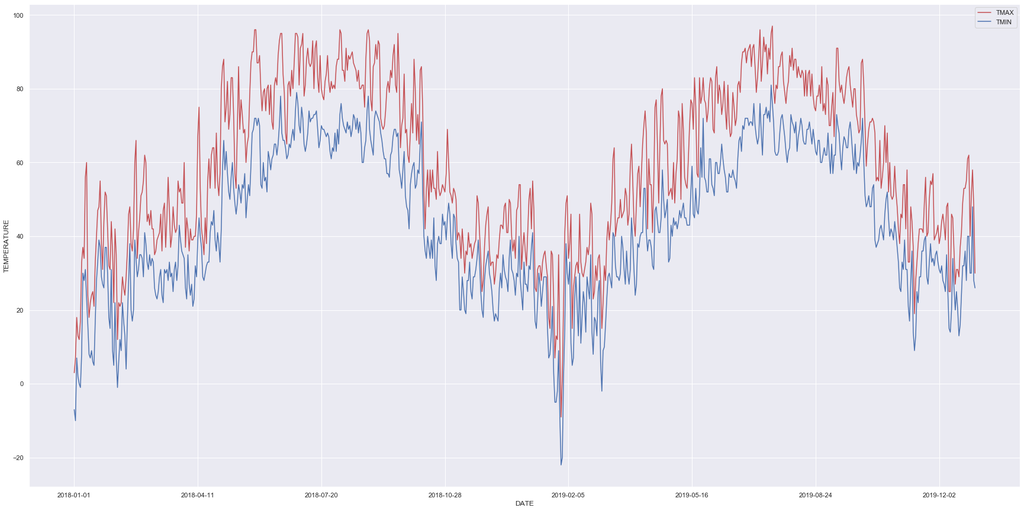

```python
sns.set(rc={'figure.figsize':(30, 15)})
ax = wdf2.plot(x="DATE", y="TMAX", color="r")
ax.set(xlabel="DATE", ylabel = "TEMPERATURE")
ax2 = ax
wdf2.plot(x="DATE", y="TMIN", ax=ax2)
plt.show()
```

**Restricting to 2018 data**

You can see from the above that we have weather data through 2019, but we want to work with 2018 only. Truncate the dataset so that it only includes temperatures from 2018.

```python
def lookup(s):
    dates = {date:pd.to_datetime(date) for date in s.unique()}
    return s.map(dates)
```

```python
wdf2['DATE'] = lookup(wdf2['DATE'])
```

```python
wdf2 = wdf2[wdf2['DATE'] <= '2018-12-31']
wdf2
```

|  | DATE | TMAX | TMIN |
| --- | --- | --- | --- |
| 32098 | 2018-01-01 | 3.0 | -7.0 |
| 32099 | 2018-01-02 | 7.0 | -10.0 |
| 32100 | 2018-01-03 | 18.0 | 7.0 |
| 32101 | 2018-01-04 | 13.0 | 2.0 |
| 32102 | 2018-01-05 | 12.0 | 0.0 |
| ... | ... | ... | ... |
| 32458 | 2018-12-27 | 54.0 | 40.0 |
| 32459 | 2018-12-28 | 54.0 | 28.0 |
| 32460 | 2018-12-29 | 31.0 | 24.0 |
| 32461 | 2018-12-30 | 37.0 | 20.0 |
| 32462 | 2018-12-31 | 41.0 | 33.0 |

365 rows × 3 columns

**Check your work**

Now check the shape of your dataset. You should have a $365x3$ matrix (date, low, high), for each date in 2018.

```python
wdf2.shape
```

```
(365, 3)
```

### 3.3 Preparing the Divvy Data

Below will provide some experience with plotting rides over time.

#### 3.3.1 Selecting the appropriate rows and columns

Depending on how you performed the last lab, you may or may not be able to re-use some code from last week. Regardless, the `groupby` function should come in handy.

**Truncate the data by date**

The truncation of the Divvy data is not perfect because it was done by searching and selecting on the CSV. Fix the truncation so that only rides starting in 2018 are included.

```python
ddf.head(5)
```

|  | TRIP ID | START TIME | STOP TIME | BIKE ID | TRIP DURATION | FROM STATION ID | FROM STATION NAME | TO STATION ID | TO STATION NAME | USER TYPE | GENDER | BIRTH YEAR | FROM LATITUDE | FROM LONGITUDE | FROM LOCATION | TO LATITUDE | TO LONGITUDE | TO LOCATION |
| --- | --- | --- | --- | --- | --- | --- | --- | --- | --- | --- | --- | --- | --- | --- | --- | --- | --- | --- |
| 0 | 18511623 | 05/21/2018 05:07:29 PM | 05/21/2018 05:11:48 PM | 153 | 259 | 51 | Clark St & Randolph St | 91 | Clinton St & Washington Blvd | Subscriber | Male | 1982.0 | 41.884576 | -87.631890 | POINT (-87.63188991 41.884576228) | 41.883380 | -87.641170 | POINT (-87.64117 41.88338) |
| 1 | 18002370 | 04/01/2018 02:24:43 PM | 04/01/2018 02:38:54 PM | 3101 | 851 | 106 | State St & Pearson St | 174 | Canal St & Madison St | Subscriber | Female | 1990.0 | 41.897448 | -87.628722 | POINT (-87.628722 41.897448) | 41.882091 | -87.639833 | POINT (-87.639833 41.882091) |
| 2 | 18002371 | 04/01/2018 02:25:30 PM | 04/01/2018 02:32:41 PM | 5226 | 431 | 426 | Ellis Ave & 60th St | 322 | Kimbark Ave & 53rd St | Subscriber | Male | 1982.0 | 41.785097 | -87.601073 | POINT (-87.6010727606 41.78509714636) | 41.799568 | -87.594747 | POINT (-87.594747 41.799568) |
| 3 | 18002372 | 04/01/2018 02:25:51 PM | 04/01/2018 02:42:22 PM | 4861 | 991 | 110 | Dearborn St & Erie St | 31 | Franklin St & Chicago Ave | Subscriber | Male | 1977.0 | 41.893992 | -87.629318 | POINT (-87.629318 41.893992) | 41.896776 | -87.635633 | POINT (-87.635633 41.896776) |
| 4 | 18002373 | 04/01/2018 02:25:58 PM | 04/01/2018 02:42:23 PM | 4706 | 985 | 214 | Damen Ave & Grand Ave | 47 | State St & Kinzie St | Subscriber | Male | 1984.0 | 41.891220 | -87.676860 | POINT (-87.67686 41.89122) | 41.889187 | -87.627754 | POINT (-87.627754 41.889187) |

```python
ddf['TRIPSDAY'] = 1
```

```python
ddf[['DATE','HOUR']] = ddf['START TIME'].str.split(" ",n=1,expand=True)
```

```python
ddf['DATE'] = lookup(ddf['DATE'])
```

```python
ddf.head(5)
```

|  | TRIP ID | START TIME | STOP TIME | BIKE ID | TRIP DURATION | FROM STATION ID | FROM STATION NAME | TO STATION ID | TO STATION NAME | USER TYPE | ... | BIRTH YEAR | FROM LATITUDE | FROM LONGITUDE | FROM LOCATION | TO LATITUDE | TO LONGITUDE | TO LOCATION | TRIPSDAY | DATE | HOUR |
| --- | --- | --- | --- | --- | --- | --- | --- | --- | --- | --- | --- | --- | --- | --- | --- | --- | --- | --- | --- | --- | --- |
| 0 | 18511623 | 05/21/2018 05:07:29 PM | 05/21/2018 05:11:48 PM | 153 | 259 | 51 | Clark St & Randolph St | 91 | Clinton St & Washington Blvd | Subscriber | ... | 1982.0 | 41.884576 | -87.631890 | POINT (-87.63188991 41.884576228) | 41.883380 | -87.641170 | POINT (-87.64117 41.88338) | 1 | 2018-05-21 | 05:07:29 PM |
| 1 | 18002370 | 04/01/2018 02:24:43 PM | 04/01/2018 02:38:54 PM | 3101 | 851 | 106 | State St & Pearson St | 174 | Canal St & Madison St | Subscriber | ... | 1990.0 | 41.897448 | -87.628722 | POINT (-87.628722 41.897448) | 41.882091 | -87.639833 | POINT (-87.639833 41.882091) | 1 | 2018-04-01 | 02:24:43 PM |
| 2 | 18002371 | 04/01/2018 02:25:30 PM | 04/01/2018 02:32:41 PM | 5226 | 431 | 426 | Ellis Ave & 60th St | 322 | Kimbark Ave & 53rd St | Subscriber | ... | 1982.0 | 41.785097 | -87.601073 | POINT (-87.6010727606 41.78509714636) | 41.799568 | -87.594747 | POINT (-87.594747 41.799568) | 1 | 2018-04-01 | 02:25:30 PM |
| 3 | 18002372 | 04/01/2018 02:25:51 PM | 04/01/2018 02:42:22 PM | 4861 | 991 | 110 | Dearborn St & Erie St | 31 | Franklin St & Chicago Ave | Subscriber | ... | 1977.0 | 41.893992 | -87.629318 | POINT (-87.629318 41.893992) | 41.896776 | -87.635633 | POINT (-87.635633 41.896776) | 1 | 2018-04-01 | 02:25:51 PM |
| 4 | 18002373 | 04/01/2018 02:25:58 PM | 04/01/2018 02:42:23 PM | 4706 | 985 | 214 | Damen Ave & Grand Ave | 47 | State St & Kinzie St | Subscriber | ... | 1984.0 | 41.891220 | -87.676860 | POINT (-87.67686 41.89122) | 41.889187 | -87.627754 | POINT (-87.627754 41.889187) | 1 | 2018-04-01 | 02:25:58 PM |

5 rows × 21 columns

```python
ddf = ddf.set_index('DATE')
```

```python
ddf = ddf.resample('1D').sum()
```

```python
ddf.head(5)
```

| DATE | TRIP ID | BIKE ID | TRIP DURATION | FROM STATION ID | TO STATION ID | BIRTH YEAR | FROM LATITUDE | FROM LONGITUDE | TO LATITUDE | TO LONGITUDE | TRIPSDAY |
| --- | --- | --- | --- | --- | --- | --- | --- | --- | --- | --- | --- |
| 2017-12-31 | 52610100 | 14185 | 3127 | 449 | 359 | 1988.0 | 125.704954 | -262.929684 | 125.706569 | -262.921522 | 3 |
| 2018-01-01 | 6576367554 | 1398434 | 249267 | 78622 | 76084 | 710128.0 | 15712.798168 | -32866.922484 | 15712.801865 | -32867.216948 | 375 |
| 2018-01-02 | 28640347053 | 6118784 | 981397 | 282266 | 283002 | 3222252.0 | 68417.296806 | -143121.384394 | 68417.313537 | -143121.356612 | 1633 |
| 2018-01-03 | 43555314553 | 9214665 | 1376291 | 442684 | 435117 | 4853169.0 | 104026.865823 | -217617.371320 | 104027.056657 | -217617.629061 | 2483 |
| 2018-01-04 | 42212356581 | 9062710 | 1334085 | 423455 | 417371 | 4710714.0 | 100803.308261 | -210869.790774 | 100802.832304 | -210869.580713 | 2406 |

```python
ddf2 = ddf.truncate(before = '2018-01-01', after = '2018-12-31')
```

```python
ddf2.head(5)
```

| DATE | TRIP ID | BIKE ID | TRIP DURATION | FROM STATION ID | TO STATION ID | BIRTH YEAR | FROM LATITUDE | FROM LONGITUDE | TO LATITUDE | TO LONGITUDE | TRIPSDAY |
| --- | --- | --- | --- | --- | --- | --- | --- | --- | --- | --- | --- |
| 2018-01-01 | 6576367554 | 1398434 | 249267 | 78622 | 76084 | 710128.0 | 15712.798168 | -32866.922484 | 15712.801865 | -32867.216948 | 375 |
| 2018-01-02 | 28640347053 | 6118784 | 981397 | 282266 | 283002 | 3222252.0 | 68417.296806 | -143121.384394 | 68417.313537 | -143121.356612 | 1633 |
| 2018-01-03 | 43555314553 | 9214665 | 1376291 | 442684 | 435117 | 4853169.0 | 104026.865823 | -217617.371320 | 104027.056657 | -217617.629061 | 2483 |
| 2018-01-04 | 42212356581 | 9062710 | 1334085 | 423455 | 417371 | 4710714.0 | 100803.308261 | -210869.790774 | 100802.832304 | -210869.580713 | 2406 |
| 2018-01-05 | 38991044324 | 8066535 | 1185644 | 393951 | 395088 | 4336767.0 | 93089.411861 | -194740.871995 | 93089.657820 | -194742.027959 | 2222 |

#### 3.3.2 Grouping by Date

```python
# Already grouped by date after **resampling**
ddf2 = ddf2[["TRIP DURATION", "TRIPSDAY"]]
```

**Group the data by date to get number of rides**

Now group the data by date so that we can align it with the weather data. Check the shape of your dataset. It should be $365x2$ (one total ride count per day).

```python
ddf2.shape
```

```
(365, 2)
```

Which date in 2018 had the most number of rides?

```python
ddf2[ddf2['TRIPSDAY']==ddf2['TRIPSDAY'].max()]
```

| DATE | TRIP DURATION | TRIPSDAY |
| --- | --- | --- |
| 2018-07-28 | 41886817 | 20663 |

**Group the data by date to get total riding time by date**

Now group the data by date so that we can align the total ride duration with the weather data. Check the shape of your dataset. It should be $365x2$ (one total duration of rides per day).

```python
ddf2.shape
```

```
(365, 2)
```

Which date in 2018 had the most riding time?

```python
ddf2[ddf2['TRIP DURATION']==ddf2['TRIP DURATION'].max()]
```

| DATE | TRIP DURATION | TRIPSDAY |
| --- | --- | --- |
| 2018-05-27 | 59152068 | 18478 |

#### 3.3.3 Visualizing the Temporal Data

As a sanity check that the Divvy data looks good and that there's a linear relationship between the datasets, let's plot the trips and duration by day (as we did last week).

[figure not shown]

```python
sns.set(rc={'figure.figsize':(20, 5)})
ax = ddf2['TRIP DURATION'].plot.area()
ax.set(ylabel = "TRIPS PER DAY")
plt.show()
```

[figure not shown]

```python
ax = ddf2['TRIPSDAY'].plot(linewidth=1)
ax.set(ylabel = "TRIP DURATION (seconds)")
plt.show()
```

### 3.3.4 Visualizing Relationships

We'll now look at a scatterplot of each of these against weather to explore the linear relationship between temperature and ride duration and number of rides.

**Join your data into a single dataframe.**

You may find it easy/useful to create a single dataframe with all of the data using the `merge` function.

```python
mdf = ddf2.merge(wdf2, left_index = True, right_on = 'DATE')
```

```python
mdf = mdf.set_index('DATE')
```

```python
mdf.head(2)
```

| DATE | TRIP DURATION | TRIPSDAY | TMAX | TMIN |
| --- | --- | --- | --- | --- |
| 2018-01-01 | 249267 | 375 | 3.0 | -7.0 |
| 2018-01-02 | 981397 | 1633 | 7.0 | -10.0 |

**Plot the scatterplots with the temperature and ride relationshps**

Provide four scatterplots:

1. Ride count vs. low temperature
2. Ride count vs. high temperature
3. Ride duration vs. low temperature
4. Ride duration vs. high temperature

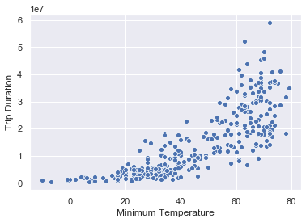

```python
%matplotlib inline
ax = sns.scatterplot(x='TMIN', y="TRIP DURATION", data=mdf)
ax.set(xlabel="Minimum Temperature", ylabel = "Trip Duration")
plt.show()
```

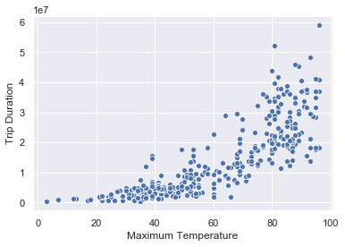

```python
ax = sns.scatterplot(x="TMAX", y="TRIP DURATION", data=mdf)
ax.set(xlabel="Maximum Temperature", ylabel = "Trip Duration")
plt.show()
```

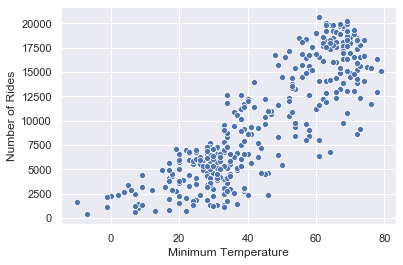

```python
ax = sns.scatterplot(x="TMIN", y="TRIPSDAY", data=mdf)
ax.set(xlabel="Minimum Temperature", ylabel = "Number of Rides")
plt.show()
```

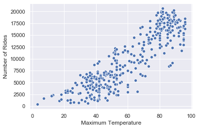

```python
ax = sns.scatterplot(x="TMAX", y="TRIPSDAY", data=mdf)
ax.set(xlabel="Maximum Temperature", ylabel = "Number of Rides")
plt.show()
```

## 4. Linear Regression

At last, we are ready to apply linear regression to our data! Note that it took a **long** time to get to this stage. This is pretty much normal for real-world data science applications: You will spend a lot of time cleaning your data before you are ready to get to the machine learning/prediction.

### 4.1. Prepare Training and Test Sets

Although our data is in the right format, don't forget that you will want to normalize the values in the dataset before applying linear regression.

Normalize all of the temperature columns in the dataset to have zero mean and standard deviation of 1. Remember to normalize against the mean and standard deviation of the training sets only, as described [here](https://sebastianraschka.com/faq/docs/scale-training-test.html).

### 4.1.1 Split into training and testing

Hold out 20% of the dataset for testing. Your test set should be randomly sampled. Be sure to use a random seed.

Hint: `scikit-learn` has useful functions for doing this for you.

```python
x = mdf[['TMAX', 'TMIN']]
y = mdf[['TRIP DURATION', 'TRIPSDAY']]
```

```python
X_train, X_test, y_train, y_test = train_test_split(x,y,test_size=0.20, random_state=42)
```

### 4.1.2 Normalize the features

Normalize the temperatures against the mean and standard deviation from the training set.

```python
def normalize(df, df_train):
    df_copy = df.copy()
    for col in df:
        df_copy[col] = ((df.loc[:,(col)] - df_train.loc[:,(col)].mean()) / df_train.loc[:,(col)].std())

    return df_copy
```

```python
X_train_normalized = normalize(X_train, X_train)
X_train_normalized.describe().round()
```

|  | TMAX | TMIN |
| --- | --- | --- |
| count | 292.0 | 292.0 |
| mean | 0.0 | 0.0 |
| std | 1.0 | 1.0 |
| min | -2.0 | -3.0 |
| 25% | -1.0 | -1.0 |
| 50% | -0.0 | -0.0 |
| 75% | 1.0 | 1.0 |
| max | 2.0 | 2.0 |

```python
X_test_normalized = normalize(X_test, X_train)
X_test_normalized.describe().round()
```

|  | TMAX | TMIN |
| --- | --- | --- |
| count | 73.0 | 73.0 |
| mean | -0.0 | -0.0 |
| std | 1.0 | 1.0 |
| min | -3.0 | -3.0 |
| 25% | -1.0 | -1.0 |
| 50% | -0.0 | -1.0 |
| 75% | 1.0 | 1.0 |
| max | 2.0 | 1.0 |

Second Approach

```python
normalizer = preprocessing.Normalizer().fit(X_train)
```

```python
X_trainnorm = pd.DataFrame(normalizer.transform(X_train))
X_testnorm = pd.DataFrame(normalizer.transform(X_test))
```

```python
X_trainnorm.describe().round()
```

|  | 0 | 1 |
| --- | --- | --- |
| count | 292.0 | 292.0 |
| mean | 1.0 | 1.0 |
| std | 0.0 | 0.0 |
| min | 1.0 | -1.0 |
| 25% | 1.0 | 1.0 |
| 50% | 1.0 | 1.0 |
| 75% | 1.0 | 1.0 |
| max | 1.0 | 1.0 |

```python
X_testnorm.describe().round()
```

|  | 0 | 1 |
| --- | --- | --- |
| count | 73.0 | 73.0 |
| mean | 1.0 | 1.0 |
| std | 0.0 | 0.0 |
| min | 0.0 | -1.0 |
| 25% | 1.0 | 1.0 |
| 50% | 1.0 | 1.0 |
| 75% | 1.0 | 1.0 |
| max | 1.0 | 1.0 |

### 4.2 Apply Linear Regression to Ride Counts

Now we're ready to apply linear regression to the datasets! The ride count target `count` appears to have more of a linear relationship with minimum and maximum temperatures. Try those first to see which is the best predictor of `count`.

#### 4.2.1 Single-Variable Linear Regression

First try each linear regression separately using `scikit-learn`'s `LinearRegression`. Report the Mean Absolute Error (MAE), Mean Squared Error (MSE) and $R^2$ for each instance.

##### 4.2.1.1 Low Temperature

**Compute the Linear Regression**

Fit a linear regression model for `count` against daily low temperatures.

```python
def do_regression(X_train, X_test, X_train_normalized, X_test_normalized, y_train, y_test, xcolumn, ycolumn):
    regr = linear_model.LinearRegression()
    target = y_train[ycolumn].values
    target_observed = y_test[ycolumn].values
    if xcolumn is "ALL":
        features = X_train_normalized
        features_notnorm = X_train
        features_test = X_test
        features_test_norm = X_test_normalized
        regr.fit(features,target)
        y_hat = regr.predict(features)
        target_predicted = regr.predict(features_test_norm)
        return target_predicted, features, target, target_observed, features_notnorm, features_test, features_test_norm, y_hat
    else:
        features = X_train_normalized[xcolumn].values.reshape(-1,1)
        features_notnorm = X_train[xcolumn].values.reshape(-1,1)
        features_test = X_test[xcolumn]
        features_test_norm = X_test_normalized[xcolumn].values.reshape(-1,1)
        regr.fit(features,target)
        y_hat = regr.predict(features)
        target_predicted = regr.predict(features_test_norm)
        return target_predicted, features, target, target_observed, features_notnorm, features_test, features_test_norm, y_hat
```

```python
target_predicted, features, target, target_observed, features_notnorm, features_test, features_test_norm, y_hat = do_regression(X_train, X_test, X_train_normalized, X_test_normalized, y_train, y_test, 'TMIN', 'TRIPSDAY')
```

**Plot the Best Fit Line Against the Complete Set of Points**

Plot minimum temperature against the number of rides in the original units (NOT the normalized units used as features when training the model) for the complete set of 365 points. Add the line of best fit from the model, and be sure to label your axes.

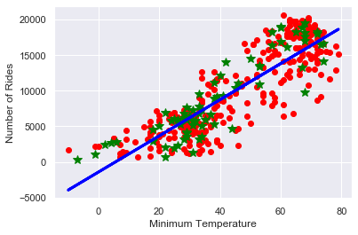

```python
plt.plot(features_notnorm, target, '.', color='red', markersize=12)
plt.plot(features_test, target_observed, '*', color='green', markersize=10)
plt.plot(features_notnorm, y_hat, color='blue', linewidth=3)

plt.xlabel('Minimum Temperature')
plt.ylabel('Number of Rides')
plt.show()
```

**Compute the Error**

Report the Mean Absolute Error (MAE), Mean Squared Error (MSE) and $R^2$ of this model on the testing set.

```python
def print_metrics(string, target_observed, target_predicted):
    print(string)
    print(" ")
    mae = metrics.mean_absolute_error(target_observed, target_predicted)
    print("Mean Absolute Error:", mae)
    mse = metrics.mean_squared_error(target_observed, target_predicted)
    print("Mean Squared Error:", mse)
    r_squared = metrics.r2_score(target_observed, target_predicted)
    print("R^2:", r_squared)
```

```python
print_metrics("**Error for linear regression model for number of trips against daily low temperatures**",target_observed, target_predicted)
```

```
**Error for linear regression model for number of trips against daily low temperatures**

Mean Absolute Error: 2139.0594742864246
Mean Squared Error: 6737729.444352465
R^2: 0.7929846229935164
```

##### 4.2.1.2 High Temperature

**Compute the Linear Regression**

As above, fit a linear regression model for `count` against daily high temperatures.

```python
target_predicted, features, target, target_observed, features_notnorm, features_test, features_test_norm, y_hat = do_regression(X_train, X_test, X_train_normalized, X_test_normalized, y_train, y_test, 'TMAX', 'TRIPSDAY')
```

**Plot the Best Fit Line Against the Complete Set of Points**

As done above, plot maximum temperature against the number of rides in the original units for the complete set of points. Add the line of best fit from the model, and be sure to label your axes.

[figure not shown]

```python
plt.plot(features_notnorm, target, '.', color='red', markersize=12)
plt.plot(features_test, target_observed, '*', color='green', markersize=10)
plt.plot(features_notnorm, y_hat, color='blue', linewidth=3)

plt.xlabel('Minimum Temperature')
plt.ylabel('Number of Rides')
plt.show()
```

**Compute the Error**

Report the Mean Absolute Error (MAE), Mean Squared Error (MSE) and $R^2$ of this model on the testing set.

```python
print_metrics("**Error for linear regression model for number of trips against daily high temperatures**",target_observed, target_predicted)
```

```
**Error for linear regression model for number of trips against daily high temperatures**

Mean Absolute Error: 1813.383709133479
Mean Squared Error: 5211698.725222164
R^2: 0.8398716087731295
```

**Interpret your results**

Which variable (between daily minimum or maximum temperature) is a better predictor of ride count? Why?

**Maximum temperature** Its R^2 is bigger which means that it explains better the variance in the number of trips. As well as lower Mean Absolute Error, which is the the average distance between each data point and the mean, and Mean Squared Error.

### 4.3 Multi-Variable Linear Regression

Now try a multiple-variable regression with both low and high temperature. Plot your results and report the error.

How does it perform compared to the single-variable methods above? Why?

```python
target_predicted, features, target, target_observed, features_notnorm, features_test, features_test_norm, y_hat = do_regression(X_train, X_test, X_train_normalized, X_test_normalized, y_train, y_test, "ALL", "TRIPSDAY")
```

```python
print_metrics("**Error for linear regression model for number of trips against daily low and high temperatures**",target_observed, target_predicted)
```

```
**Error for linear regression model for number of trips against daily low and high temperatures**

Mean Absolute Error: 1808.7490889509245
Mean Squared Error: 5053420.214169953
R^2: 0.8447346840729195
```

**Incorporating more weather data**

Include daily precipitation and snowfall from the NOAA data in your multi-variable regression. Remember to normalize the new variables.

Of the four variables now in your model, which is the best predictor of ride count? Why?

```python
wdf3 = wdf[wdf['STATION'] == 'USC00111577']
wdf3 = wdf3[["DATE", "PRCP", "SNOW", "TMAX", "TMIN" ]]
wdf3['DATE'] = lookup(wdf3['DATE'])
wdf3 = wdf3[wdf3['DATE'] <= '2018-12-31']

mdf2 = ddf2.merge(wdf3, left_index = True, right_on = 'DATE')
mdf2 = mdf2.set_index('DATE')
```

```python
x = mdf2[['PRCP','SNOW','TMAX', 'TMIN']]
y = mdf2[['TRIP DURATION', 'TRIPSDAY']]

X_train_m, X_test_m, y_train_m, y_test_m = train_test_split(x,y,test_size=0.20, random_state=42)

X_train_norm_m = normalize(X_train_m, X_train_m)
X_test_norm_m = normalize(X_test_m, X_train_m)
```

```python
target_predicted, features, target, target_observed, features_notnorm, features_test, features_test_norm, y_hat = do_regression(X_train_m, X_test_m, X_train_norm_m, X_test_norm_m, y_train_m, y_test_m, "ALL", "TRIPSDAY")
```

```python
print_metrics("**Error for linear regression model for number of trips against daily low and high temperatures ADDED VARIABLES**",target_observed, target_predicted)
```

```
**Error for linear regression model for number of trips against daily low and high temperatures ADDED VARIABLES**

Mean Absolute Error: 1776.9058422547998
Mean Squared Error: 5012083.58017252
R^2: 0.8460047438077061
```

```python
coeff_df = pd.DataFrame(regr.coef_, X_test_m.columns, columns=['Coefficient'])
coeff_df
```

[output not shown]

*This means that for one standard deviation more in "daily precipitation", there is a decrease of 1,379 rides. For one standard deviation more in "snowfall", there is an increase of ~73 rides. For every standard deviation more in "maximum temperature", there is an incrase of ~4,044 rides. Similarly, for every standard deviation more in "minimum temperature", there is an increase of ~1,364 rides. As a conclusion, after running multi-variable regression, apparently "maximum temperature" is the best predictor of ride count.*

### 4.4 Polynomial Transformations of Predictors

Look back at your scatterplot of ride duration vs. daily high/low temperatures. The relationship between temperature and ride duration appears to better fit a polynomial (rather than a linear) function.

First fit a linear regression predicting `duration` using the two features of high and low temperatures. Then, apply a polynomial transformation to these predictors (e.g. square them) to see if this yields a better fit. Explain your results.

```python
target_predicted, features, target, target_observed, features_notnorm, features_test, features_test_norm, y_hat = do_regression(X_train, X_test, X_train_normalized, X_test_normalized, y_train, y_test, "ALL", "TRIP DURATION")
```

```python
print_metrics("**Error for linear regression model for trip duration against daily low and high temperatures**",target_observed, target_predicted)
```

```
**Error for linear regression model for trip duration against daily low and high temperatures**

Mean Absolute Error: 4238331.789521003
Mean Squared Error: 27548653830569.695
R^2: 0.7485291728380306
```

```python
from sklearn.preprocessing import PolynomialFeatures
poly = PolynomialFeatures(degree = 2, include_bias = True)
pf = poly.fit_transform(X_train_normalized)
pft = poly.fit_transform(X_test_normalized)
```

```python
ptarget_predicted, pfeatures, ptarget, ptarget_observed, pfeatures_notnorm, pfeatures_test, pfeatures_test_norm, py_hat = do_regression(X_train, X_test, pf, pft, y_train, y_test, "ALL", "TRIP DURATION")
```

```python
print_metrics("**Error for polynomial regression model for trip duration against daily low and high temperatures**",ptarget_observed, ptarget_predicted)
```

```
**Error for polynomial regression model for trip duration against daily low and high temperatures**

Mean Absolute Error: 3311849.6743549453
Mean Squared Error: 20115023341185.55
R^2: 0.8163851638958415
```

*The error measures are better for the polynomial regression, since R^2 is higher (0.81 vs 0.74) and errors are smaller, which means that regression with polynomial features better fits the data related with duration trips.*

### 4.5 Regularization

We will cover the topic of regularization in class next week. For now, try out the `Ridge` and `Lasso` linear models in place of `LinearRegression`. In particular, explore how different values of the `alpha` parameter affect performance. (Hint: the `scikit-learn` documentation for [Ridge](https://scikit-learn.org/stable/modules/generated/sklearn.linear_model.Ridge.html) and [Lasso](https://scikit-learn.org/stable/modules/generated/sklearn.linear_model.Lasso.html) will be helpful.)

Comment on your results from changing this parameter when fitting models predicting `duration` using the four features used above (minimum temperature, maximum temperature, precipitation, and snowfall). How did changing the regularization parameter affect performance? Note that this question is intentionally meant to be open-ended to give you a chance to experiment with these parameters.

```python
for i in range(0,1100,100):
    ls = linear_model.Lasso(alpha=i)
    rg = linear_model.Ridge(alpha=i)
    en = linear_model.ElasticNet(alpha=i)

    models = [(ls, 'Lasso'),
               (rg, 'Ridge'),
               (en, 'Elastic Net')]
    print('\n\033[1m' + 'Alpha set to: {}'.format(i) + '\033[0m\n')
    for m in models:
        (model,name) = m
        model.fit(features, target)
        target_predict = model.predict(features_test_norm)
        print('{}\n{}\n'.format(name,model.coef_))
        print_metrics("**Error for linear regression model for trip duration against daily low and high temperatures**",
                      target_observed, target_predict)
```

```
Alpha set to: 0

Lasso
[7798712.08880337 2347230.52508463]

**Error for linear regression model for trip duration against daily low and high temperatures**

Mean Absolute Error: 4238331.789521005
Mean Squared Error: 27548653830569.7
R^2: 0.7485291728380306
Ridge
[7798712.08880344 2347230.52508456]

**Error for linear regression model for trip duration against daily low and high temperatures**

Mean Absolute Error: 4238331.789521009
Mean Squared Error: 27548653830569.72
R^2: 0.7485291728380303
Elastic Net
[7798712.08880337 2347230.52508463]

**Error for linear regression model for trip duration against daily low and high temperatures**

Mean Absolute Error: 4238331.789521005
Mean Squared Error: 27548653830569.7
R^2: 0.7485291728380306

Alpha set to: 100

Lasso
[7801219.29915513 2344718.8233039 ]

**Error for linear regression model for trip duration against daily low and high temperatures**

Mean Absolute Error: 4238460.932821543
Mean Squared Error: 27549245683260.01
R^2: 0.748523770262409
Ridge
[4589681.96549726 4043915.68146669]

```

[output cut: 241 more lines]

```
[1873569.50498874 1813588.46172314]

**Error for linear regression model for trip duration against daily low and high temperatures**

Mean Absolute Error: 6756475.474296199
Mean Squared Error: 60613309773123.11
R^2: 0.44670693386992444
Elastic Net
[19965.26494859 19549.89701686]

**Error for linear regression model for trip duration against daily low and high temperatures**

Mean Absolute Error: 9646009.866140028
Mean Squared Error: 116748667393595.67
R^2: -0.06571029350794344
```